# Estimating chi

This notebook imports the spectral data saved from matlab, corrects for the frequency response of the sensor using Vachon and Lueck correction (used by Rockland in odas and by Bluteau) and tries to fit the model stated in Bluteau to the spectrum.

Data from profile 032 was used for testing, dive depth was 414 m. 146 spectra were calculated.

##### Following questions:

- which range of wavenumbers ($k$) to fit model to?
- the answer can be found in Bluteau, minimum $k$ depends on a ‘goodness of fit’ criteria MAD, maximum $k$ depends on $\epsilon \le 0.1 \eta$ with $\eta$ = Kolmogorov length scale = $(\frac{\nu^3}{\epsilon})^\frac{1}{4}$ ($\nu$ = kinematic viscosity, $~10^{-6}$ for water at $20^\circ C$)
- data spectrum doesnt really increase towards higher wave numbers, like in spectra in Bluteau –> tried different things, (i) checked that data are detrended, linear detrending doesn’t seem to have much effect; (ii) tried HP filtering -> using a filter with stopband at 1/4 fft_length and passband at 1/2 fft_length and 100% attenuation, a bit better than linear detrending, but there are still a lot of spectra where spectrum increases towards the low wavenumbers
- model doesn’t seem to fit data very well, why?, do I miss some more transformation of spectrum?
- do I have to convert from cpm to rad/m? –> no, but add the conversion from rad/m to cpm to the model constant $C_T$ (not 100% clear though, whether necessary)

### Reading in the data

```r
# read in data, mat structures are read as lists in R
spec <- readMat('../data/gradT_spectra_HPfilt_fftl2.mat')
diss <- readMat('../data/Diss_032_fft2.mat')
diss_fieldnames <- unlist(readMat('../data/diss_fieldnames_fft2.mat'))
```

```r
# extract spectrum energy values from spec list
gradT1 <- spec[[1]][[1]][,1,]
gradT2 <- spec[[1]][[1]][,2,]
```

```r
# wavenumber 2D matrix with each column for one depth segment from spec list
waven1 <- spec[[1]][[3]]
# frequency matrix from spec list
freq <- spec[[1]][[2]]
```

```r
# additional variables
mean_speed <- diss[[1]][[16]]
pressure <- diss[[1]][[18]]
eps <- diss[[1]][[1]]
eps1 <- eps[1,]
eps2 <- eps[2,]
# delete unused variables
rm(diss)
rm(spec)
```

Dimensions of some variables: `gradT1`: 1025, 146, `freq`: 1025, 146, `waven1`: 1025, 146, `eps1`: 146

### Correcting for frequency response

The following calculations are done exemplary for only one temperature sensor.

- expression for tau from odas library

```r
# correction as in odas library
F_0 <- 25*sqrt(mean_speed)
tau_therm <- 2*pi*F_0 / sqrt(sqrt(2) - 1)   # time constant for double-pole response
tau_therm <- 1 / tau_therm
# correction:
gradT1_c <- matrix(data=NA, nrow=length(freq[,1]), ncol=length(freq[1,]))
for(index in 1:length(freq[1,])){
  gradT1_c[,index] <- gradT1[,index] * (1 + (2*pi*tau_therm[index]*freq[,index])^2)^2
}
gradT2_c <- matrix(data=NA, nrow=length(freq[,1]), ncol=length(freq[1,]))
for(index in 1:length(freq[1,])){
  gradT2_c[,index] <- gradT2[,index] * (1 + (2*pi*tau_therm[index]*freq[,index])^2)^2
}
```

#### Plot of uncorrected and corrected sample spectra

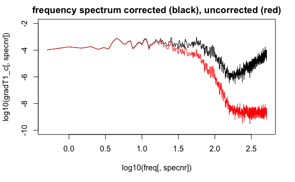

### Fit model to spectra with chi as parameter estimated with MLE

model to fit:
$$\Psi_{\delta T/\delta x_i}(k) = C_T \chi \epsilon^{-1/3} k^{1/3}$$

with $\Psi_{\delta T/\delta x_i}$ = corrected energy spectrum,

$C_T$ = Obukhov-Corrsin universal constant with values between 0.3 and 0.5, 0.4 recommended,

and $k$ = wavenumber ($k$ is here in rad/m, a conversion coefficient to convert to cpm should be added to the model?)

#### Try MLE (maximum likelihood estimation) fitting

##### 1) Convert measured spectra to wavenumber spectra by multiplying with mean_speed

Dimension of corrected spectra `gradT1_c` is 1025, 146

```r
# make empty (NA) matrix of correct size
P_gradT1_c <- matrix(NA, nrow = length(gradT1_c[,1]), ncol=length(gradT1_c[1,]))
P_gradT2_c <- matrix(NA, nrow = length(gradT2_c[,1]), ncol=length(gradT2_c[1,]))
# fill matrix with converted values
for(index in 1:length(gradT1_c[,1])){
  P_gradT1_c[index,] <- gradT1_c[index,] * mean_speed
  P_gradT2_c[index,] <- gradT2_c[index,] * mean_speed
}
```

##### 2) find highest value for $k$ to include in fit using the criterium correction $H(k) \leq 3$

```r
K_max <- c()
for(segment in 1:146){
  # calculate correction factor
  f <- freq[,segment]
  tau0 <- 4.1 * 10^-3
  speed0 <- 1
  tau <- tau0 * (mean_speed[segment,]/speed0)^(-0.5)
  Hf <- (1 + (2 * pi * tau *f)^2)^(2)
  # find index where Hf does not exceed 3
  ind <- length(Hf[Hf <= 3])
  # find K at ind
  K_max_seg = waven1[ind,segment]

  # K must never be higher than 0.1 * eta^-1 (eta = Kolmogorov length scale)
  eta <- (((10^-6)^3)/mean(eps1[segment],eps2[segment]))^0.25 # Kolmogorov length scale
  # final upper limit of k
  K_max[segment] <- min(0.1/eta,K_max_seg)
}
```

##### 5) define x and y for model, only use spectrum for wavenumbers < K_max and > K_min

```r
x <- list()
y <- list()
for(segment in 1:146){
  # K_min needs to be checked after fitting, default value = 0
  K_min <- 0 #waven1[2*steps+2,segment] #0
  min_ind <- max(length(waven1[waven1[,segment]<=K_min, segment]),2)
  max_ind <- length(waven1[waven1[,segment]<=K_max[segment],segment]) # index for   subsetting model values
  # y values are corrected wavenumber temp-gradient spectrum --> P_gradT1_c for chosen   k range
  y_seg <- P_gradT1_c[min_ind:max_ind,segment]
  # x values are k for chosen range
  x_seg <- waven1[min_ind:max_ind,segment]
  y <- c(y,list(y_seg))
  x <- c(x,list(x_seg))
}
```

##### 6) Definition of maximum likelihood function

```r
fit <- list()
chi <- c()
for(segment in 1:146){
  xs <- x[[segment]]
  ys <- y[[segment]]
  #likelihood function definition
  LL <- function(chi) {
    # Find residuals
    R = ys - C_T * chi * mean(eps1[segment],eps2[segment])^(-1/3) * xs^(1/3)
    # Calculate the likelihood for the residuals
    R = suppressWarnings(dnorm(R, log = TRUE))
    # Sum the log likelihoods for all of the data points
    -sum(R)
  }

  #model fit
  fit_seg <- suppressWarnings(mle(LL, start = list( chi=10^(-7))
                              ,nobs = length(ys),  method='L-BFGS-B'))
  fit <- c(fit, list(fit_seg))
  chi <- c(chi, fit_seg@coef[[1]])
}
```

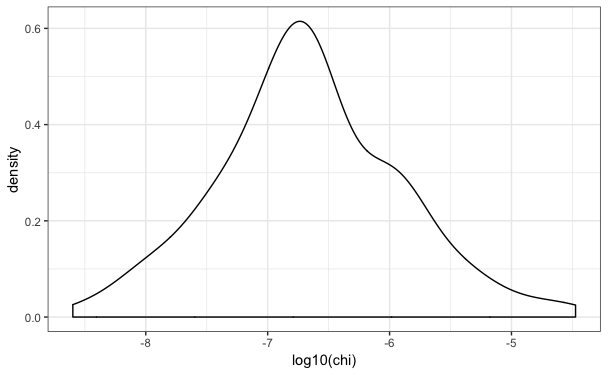

```r
# distribution chi
ggplot(data = data.frame(pressure, chi, eps1)) +
  geom_density(aes(x = log10(chi))) +
#  geom_density(aes(x = log10(eps1)), col = 'red') +
  theme_bw()
```

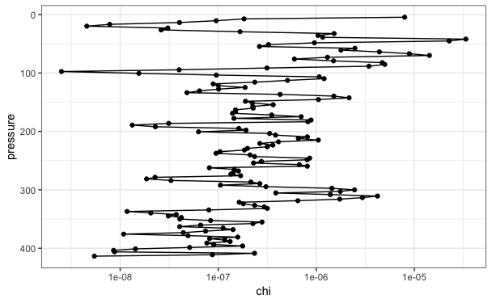

```r
# plot chi over pressure
ggplot(data = data.frame(pressure, chi)) +
  geom_point(aes(x = pressure, y = chi)) +
  geom_line(aes(x = pressure, y = chi)) +
  coord_flip() +
  scale_x_reverse() +
  scale_y_log10() +
  theme_bw()
```

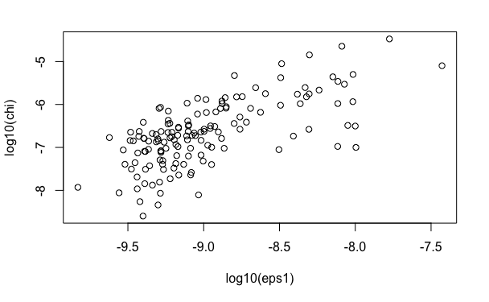

```r
# plot eps vs chi
plot(log10(eps1), log10(chi))
```

##### 8) calculate model with fitted $\chi$ for plotting

```r
spec_model <- list()
for(segment in 1:146){
  spec_model_seg <-  C_T * fit[[segment]]@coef[1] * mean(eps1[segment],eps2[segment])^(-1/3) * x[[segment]]^(1/3)
  spec_model <- c(spec_model, list(spec_model_seg))
}
```

##### 9) check for lower K condition using MAD (mean absolute deviation) on observed and modelled spec

```r
MAD <- list()
crit <- list()
spec_good <- c()
for(segment in 1:146){
  phi <- y[[segment]]   # corrected wavenumber temp-gradient = measured spectrum
  psi <- spec_model[[segment]]   # modelled spectrum
  steps <- 6  # 0.5-0.7 of a decade long?
  nr_steps <- floor(length(phi)/steps)
  modulo <- length(phi) %% steps
  if(modulo >= 4){
    nr_steps <- nr_steps + 1
  }
  # calculate MAD for steps of 6 values for the spectrum
  MAD_seg <- c()
  crit_seg <- c()
  for(i in 1:nr_steps){
    n_st <- (i-1) * steps + 1
    if(i == nr_steps){
      if(modulo >= 4){
        n_en <- n_st + modulo - 1
      }else{
        n_en <- n_st + steps - 1 + modulo
      }
    }else{
      n_en <- n_st + steps - 1
    }
    phi_n = phi[n_st:n_en]
    psi_n = psi[n_st:n_en]
    MAD_seg[i] <-  1/(length(phi_n)) * sum(abs(phi_n/psi_n - mean(phi_n/psi_n)))

    # check whether MAD fits criteria, crit = 0 (bad), 1 (good)
    dof <- length(phi_n) - 1   # degrees of freedom
    crit_seg[i] <- ifelse(MAD_seg[i] < 2 * (2/dof)^0.5, 1, 0)

  } # end for loop
  MAD <- c(MAD, list(MAD_seg))
  crit <- c(crit, list(crit_seg))
  spec_good <- c(spec_good, ifelse(sum(crit_seg)==length(crit_seg),1,0))
}
#If all subsets of the spectrum yielded a MAD>2(2/d)^1/2 (d = degrees of freedom --> n-1 ?) (Ruddick et al. 2000), then the spectrum is completely discarded. Otherwise, the final wavenumber range used to obtain xF starts at the lowest wavenumber at which MAD<2(2/d)^1/2
```

There are 70 good spectra in the profile.

```r
# find how many steps are to be discarded from spectra, where some pts don't fulfil MAD criterium --> should there be a minimum of points left for fitting model? (each step has about 6 points)
bad_steps <- c()
for(segment in 1:146){
  bad_steps[segment] <- length(crit[[segment]]) - sum(crit[[segment]])
}
```

```r
# fit linear model to check
slope <- c()
interc <- c()
for(segment in 1:146){
# fit a linear model to check
linearmod <- lm(log10(y[[segment]]) ~ log10(x[[segment]]))
slope[segment] <- signif(linearmod$coefficients[2],3)
interc[segment] <- linearmod$coefficients[1]
}
```

10. plot data and model

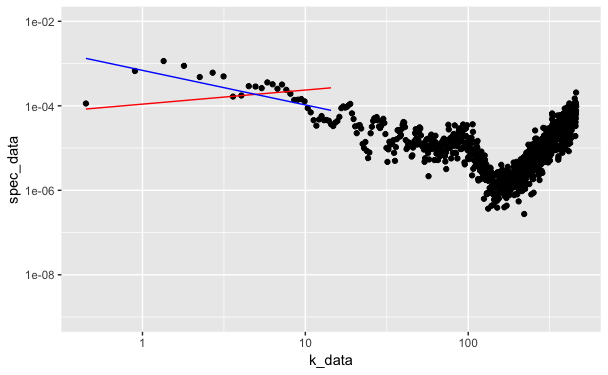

```r
#for(segment in 1:146)
  segment <- 80
pl_data <- data.frame(k_data=waven1[-1,segment], spec_data=P_gradT1_c[-1,segment])
pl_model <- data.frame(k_model = x[[segment]], spec_model = spec_model[[segment]])
pl_linm <- data.frame(linm_x = x[[segment]], linm_y = 10^(slope[segment]*log10(x[[segment]])+interc[segment]))
ggplot() +
  geom_point(data=pl_data, aes(x=k_data, y = spec_data)) +
  geom_line(data=pl_model, aes(x=k_model, y=spec_model), color='red') +
  scale_y_continuous(trans='log10', limits=c(10^-9,10^-2)) +
  scale_x_continuous(trans='log10') + #, limits=c(x[1],K_max)) +
  geom_line(data = pl_linm, aes(x=linm_x, y = linm_y), color = 'blue')
```